# work_normalization-etc_rough-draft

##### Approach 2: Don’t use `controlGenes`; use all features for normalization

That is, include all of both *K. lactis* and *S. cerevisiae* features in the size-factor estimation.

```r
dds_2 <- BiocGenerics::estimateSizeFactors(dds)
dds_2@colData
```

```
DataFrame with 4 rows and 9 columns
                                   strain    state     time      kit transcription
                                 <factor> <factor> <factor> <factor>      <factor>
WT_G1_day1_ovn_N_aux-F_tc-F_rep1       WT       G1     day1      ovn             N
WT_G1_day1_ovn_N_aux-F_tc-F_rep2       WT       G1     day1      ovn             N
WT_Q_day7_ovn_N_aux-F_tc-F_rep1        WT       Q      day7      ovn             N
WT_Q_day7_ovn_N_aux-F_tc-F_rep2        WT       Q      day7      ovn             N
                                    auxin timecourse replicate sizeFactor
                                 <factor>   <factor>  <factor>  <numeric>
WT_G1_day1_ovn_N_aux-F_tc-F_rep1    aux-F       tc-F      rep1   0.622333
WT_G1_day1_ovn_N_aux-F_tc-F_rep2    aux-F       tc-F      rep2   0.638943
WT_Q_day7_ovn_N_aux-F_tc-F_rep1     aux-F       tc-F      rep1   1.522589
WT_Q_day7_ovn_N_aux-F_tc-F_rep2     aux-F       tc-F      rep2   1.687240
```

```r
#  Not using controlGenes; using all features
# G1 rep1 0.622333
# G1 rep2 0.638943
#  Q rep1 1.522589
#  Q rep2 1.687240
```

##### Approach 3: No `controlGenes` and include only *S. cerevisiae* features

That is, use only *S. cerevisiae* features in the size-factor estimation.

```r
dds_3 <- BiocGenerics::estimateSizeFactors(
    dds[dds@rowRanges$genome != "K_lactis", ]
)
dds_3@colData
```

```
DataFrame with 4 rows and 9 columns
                                   strain    state     time      kit transcription
                                 <factor> <factor> <factor> <factor>      <factor>
WT_G1_day1_ovn_N_aux-F_tc-F_rep1       WT       G1     day1      ovn             N
WT_G1_day1_ovn_N_aux-F_tc-F_rep2       WT       G1     day1      ovn             N
WT_Q_day7_ovn_N_aux-F_tc-F_rep1        WT       Q      day7      ovn             N
WT_Q_day7_ovn_N_aux-F_tc-F_rep2        WT       Q      day7      ovn             N
                                    auxin timecourse replicate sizeFactor
                                 <factor>   <factor>  <factor>  <numeric>
WT_G1_day1_ovn_N_aux-F_tc-F_rep1    aux-F       tc-F      rep1   1.144887
WT_G1_day1_ovn_N_aux-F_tc-F_rep2    aux-F       tc-F      rep2   1.166906
WT_Q_day7_ovn_N_aux-F_tc-F_rep1     aux-F       tc-F      rep1   0.784023
WT_Q_day7_ovn_N_aux-F_tc-F_rep2     aux-F       tc-F      rep2   0.970161
```

#### Do rlog normalization: `WT_{G1,Q}_day7_ovn_N_aux-F_tc-F_rep{1,2}`

On the `blind` option: “`logical`, whether to blind the transformation to the experimental design. `blind = TRUE` should be used for comparing samples in a manner unbiased by prior information on samples, for example to perform sample QA (quality assurance). `blind = FALSE` should be used for transforming data for downstream analysis, where the full use of the design information should be made. `blind = FALSE` will skip re-estimation of the dispersion trend if this has already been calculated. If many of genes have large differences in counts due to the experimental design, it is important to set `blind = FALSE` for downstream analysis.”

[output not shown]

[output cut: 990 more lines]

### Run `DESeq2`: `WT_{G1,Q}_day7_ovn_N_aux-F_tc-F_rep{1,2}`

#### Call `DESeq2` using default parameters

Since we’ve already calculated the size factors, I think we can exclude *K. lactis* features from our work from here on out

```r
dds_1_all <- DESeq2::DESeq(dds_1)
dds_2_all <- DESeq2::DESeq(dds_2)
dds_1_sub <- DESeq2::DESeq(dds_1[dds_1@rowRanges$genome != "K_lactis", ])
dds_2_sub <- DESeq2::DESeq(dds_2[dds_2@rowRanges$genome != "K_lactis", ])
dds_3 <- DESeq2::DESeq(dds_3)
```

#### Call `DESeq2::results()`

```r
#  Output a DESeq2 DataFrame object
DGE_unshrunken_DF_1 <- DESeq2::results(
    dds_1,
    name = DESeq2::resultsNames(dds_1)[2],
    independentFiltering = independent_filtering,
    alpha = threshold_p,
    lfcThreshold = threshold_lfc,
    format = "DataFrame"
)
```

```
Error in DESeq2::results(dds_1, name = DESeq2::resultsNames(dds_1)[2],  :
  couldn't find results. you should first run DESeq()
```

#### Make an MA plot

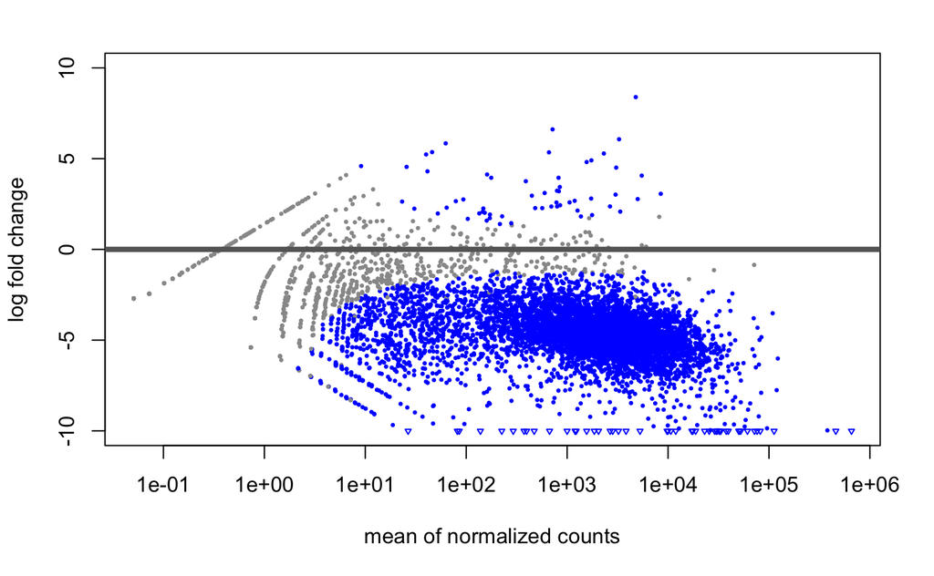

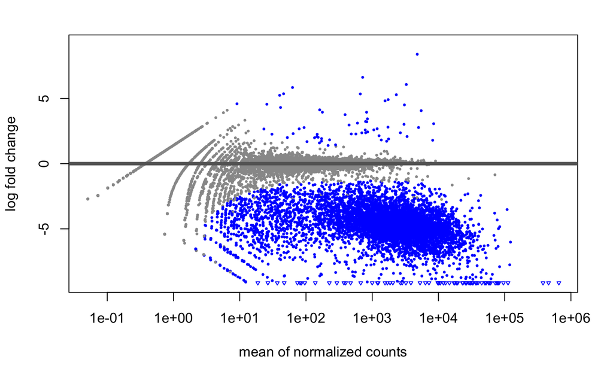

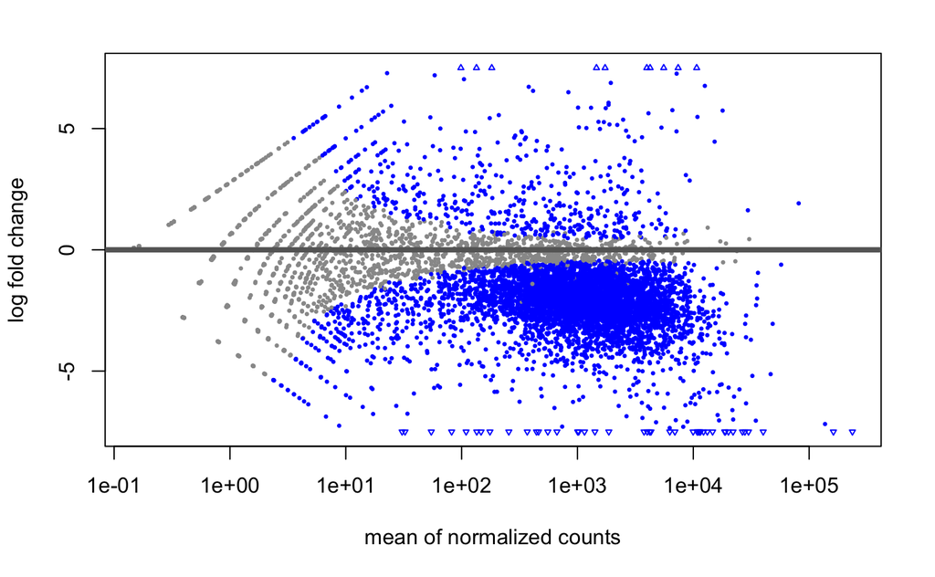

```r
BiocGenerics::plotMA(DGE_unshrunken_DF_1_sub)
BiocGenerics::plotMA(DGE_unshrunken_DF_1_all)


BiocGenerics::plotMA(DGE_unshrunken_DF_2_sub)
```

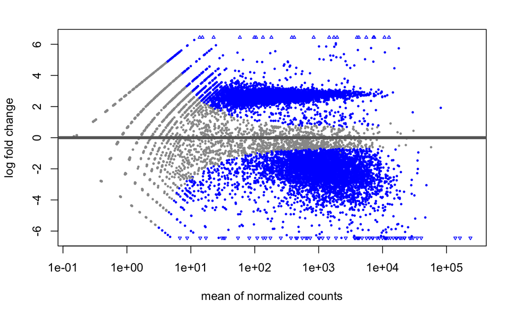

```r
BiocGenerics::plotMA(DGE_unshrunken_DF_2_all)
```

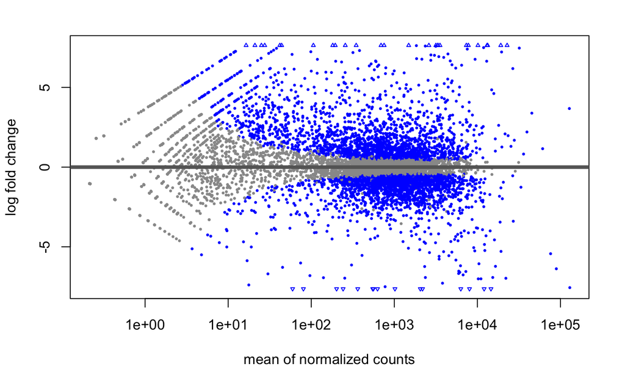

```r
BiocGenerics::plotMA(DGE_unshrunken_DF_3)
```